# 期末專題

周茹襄

2022/1/26

### 臺灣家庭借款置產的時序變化

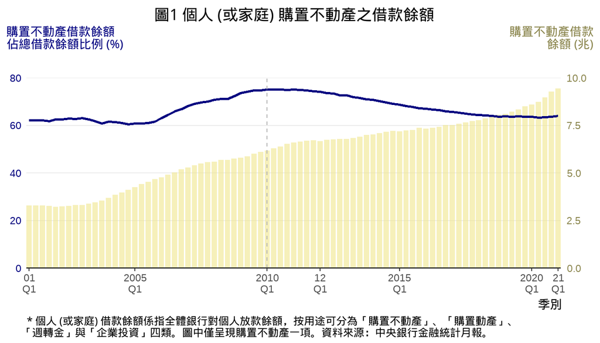

### 臺灣都會區房價成長率

- 「新屋、預售屋房價指數」為內政部住宅統計所收錄國泰房地產價格指數內的可能成交指數，透過成交價格波動狀況判斷市場成交行情，含預售及新成屋物件；而「中古屋房價指數」則是信義房屋的全臺都會區季指數，採樣範圍含公寓、華廈及電梯大樓等純住產品，並排除預售物件、具備其他用途之住宅物件與偏差樣本 (工業住宅、屋齡偏高之成交物件)。兩項指數均透過產學合作，以公司內部的仲介成交資料為基礎，利用特徵價格函數 (Hedonic Price Model) 理論配合拉氏指數公式 (Laspeyres) 編製而成，分別在全臺的新成屋、預售屋市場及國內純住中古屋市場具有指標性。
- 統一將房價指數基期調整為 2016 年，繪製成 圖2 將發現臺灣六大都會區 (雙北、桃竹、臺中與高雄) 房價在 2019Q4 至 2020Q4 均為正成長。其中，以桃園市為新屋、預售屋房價年成長最高者 (11.3%)，而新竹縣市的中古屋房價年成長為 13.5%，遠超過臺灣全區的 6.5%。
- 圖2 各都會區房價年成長，又以新竹、高雄、臺中、新北等地區之中古屋漲幅比率遠大於新屋、預售屋；臺北市則以新屋、預售屋的房價年成長為大，或許是北部開發較早，土地所剩無幾，也可能是新建案內的高價住宅所致。

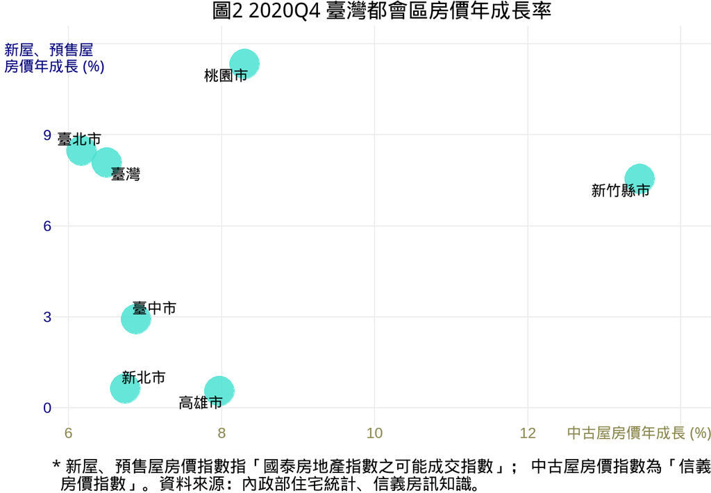

### 臺灣實際居住與戶籍人口差異

- 參考「電信信令人口統計之建置、分析與應用」(內政部統計處，2021)，電信業者 (中華電、台哥大與遠傳) 於 109 年 11 月，將扣除企業戶之電信信令用戶資料以 10 分鐘為單位，記錄電信使用人口最常出現之所在經緯度位置，且最小統計區約為 1/20 個村里，而資料期間則細分為平日及假日兩種。
- 而「夜間停留用戶數」則是電信業者將 19:00~07:00 期間，用戶之電信信令最常出現的最小統計區，視為該用戶之夜間停留地，並統計各最小統計區的所有用戶數而取得。
- 若以夜間停留用戶數表示實際居住人口，將能配合戶籍人口取得人口「淨流入(%)」。以週間而言，將可能因為工作或學業而使文教地區或是產業重鎮產生「淨流入(%)」，由 圖3 可知，出現淨流入的區域多於北部、西部，以及東部零星的沿海地區。
- 觀察 圖3，實居人口超過戶籍人口兩倍的區域有新竹新豐、寶山、竹東，苗栗竹南，四個行政區就有三個隸屬新竹，剛好呼應 圖2 新竹的房價高成長率。而實居人口超過戶籍人口 1 倍的地區則是彰化的員林、二林。

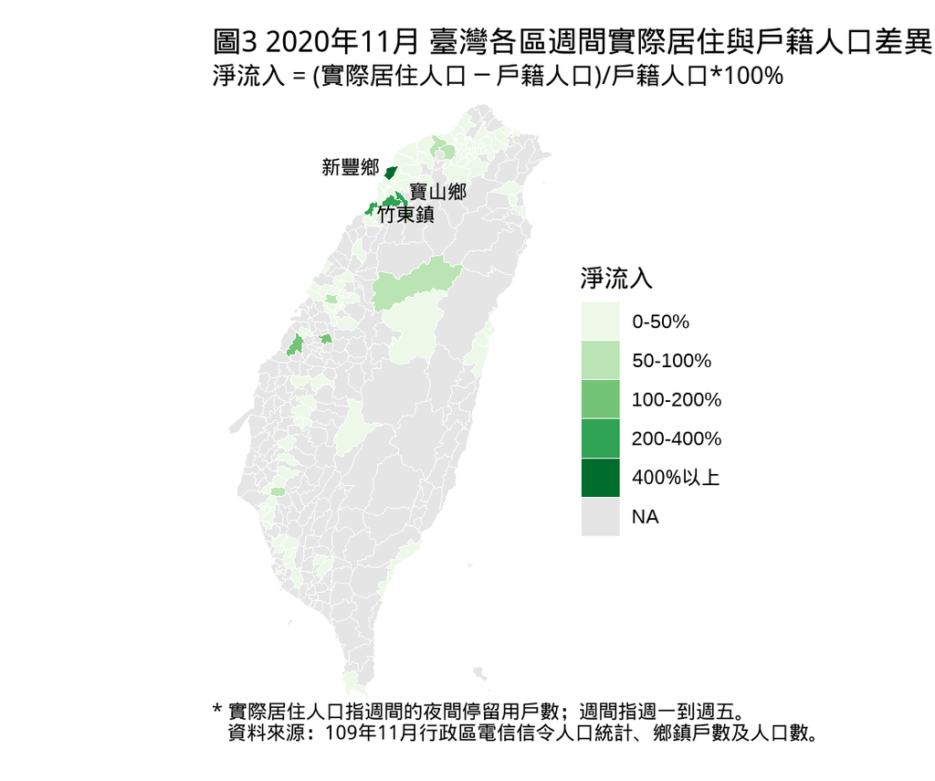